# Cvičenie 4: ARMA procesy, testovanie jednotkového koreňa

# 1 Inštalácia knižníc v R-ku

Začneme s inštaláciou knižníc potrebných na toto cvičenie. Spustením nasledovného príkazu sa nainštalujú tie z knižníc, ktoré nainštalované nie sú, a zároveň sa aj načítajú.

```r
# názvy balíkov, ktoré budú potrebné pre cvičenie 4
packages <- c("astsa", "urca", "datasets", "ggplot2")

# inštalácia balíkov, ak nie sú nainštalované
installed_packages <- packages %in% rownames(installed.packages())
if (any(installed_packages == FALSE)) {
  install.packages(packages[!installed_packages],dependencies=TRUE)
}

# načítanie balíkov
invisible(lapply(packages, library, character.only = TRUE))
```

# 2 Autokorelačná funkcia AR procesu

Nájdeme autokorelačnú funkciu AR(3) procesu
$$x_t=1.5x_{t−1}−0.8x_{t−2}+0.2x_{t−3}+u_t$$

Ukážeme si dva spôsoby riešenia:

- priamo z Yule-Wolkerových rovníc a diferenčnej rovnice z prednášky,
- pomocou funkcie v R-ku.

## 2.1 Z Yule Wolkerových rovníc

Pri tomto spôsobe riešenia je prvým krokom zostavenie Yule-Wolkerových rovníc. Tie následne vyriešime v R-ku. Dostaneme ACF(k) pre $k=1,2,3$ (pozrite `?matrix`, `?solve`). Následne v cykle z diferenčnej rovnice vypočítame ďalšie hodnoty ACF.

```r
rho <- rep(0, times=10)
rho <- ....                   # prve tri zlozky ako riesenie sustavy
for (i in 4:19) rho[i] <- ... # ostatne zlozky z diferencnej rovnice
```

Výstup pre kontrolu:

```
##  [1] 0.9178082 0.7602740 0.6061644 0.4845890 0.3940068 0.3245719 0.2685702
##  [8] 0.2219991 0.1830569 0.1507001
```

## 2.2 Funkcia v R-ku

Použijeme funkciu `ARMAacf` pre náš proces.

```r
ARMAacf(ar=c(...), lag.max=10)
```

Výstup pre kontrolu:

```
##         0         1         2         3         4         5         6         7
## 1.0000000 0.9178082 0.7602740 0.6061644 0.4845890 0.3940068 0.3245719 0.2685702
##         8         9        10
## 0.2219991 0.1830569 0.1507001
```

Porovnajte výsledky z oboch postupov. Funkcia `ARMAacf` by už nemala byť “čiernou skrinkou” :).

# 3 Parciálna autokorelačná funkcia AR procesu

## 3.1 Opakovanie z prednášky

- Čo je parciálna autokorelačná funkcia procesu?
- Čím je charakteristická PACF autoregresného procesu rádu p? Prečo? Ako to vyplýva z definície PACF?

## 3.2 Výpočet v R-ku

Nájdeme parciálnu autokorelačnú funkciu AR(3) procesu
$$x_t=1.5x_{t−1}−0.8x_{t−2}+0.2x_{t−3}+u_t$$

Podobne ako v prípade ACF, aj teraz použijeme funkciu `ARMAacf`, ale pridáme parameter `pacf=TRUE`.

```r
ARMAacf(ar=c(...), lag.max=10, pacf=TRUE)
```

```
##  [1]  9.178082e-01 -5.208333e-01  2.000000e-01  0.000000e+00  5.033930e-16
##  [6] -1.123254e-15  8.351739e-16  9.367857e-17 -6.465462e-16  5.159779e-16
```

## 3.3 Výberová PACF z dát

Môžeme

- použiť funkciu `pacf`,
- pomocou funkcie `acf2` z knižnice `astsa` vykresliť naraz výberovú ACF aj PACF (tu bude mať navyše ACF odstránenú hodnotu pre lag 0, ktorá sa vždy rovná 1).

Napríklad:

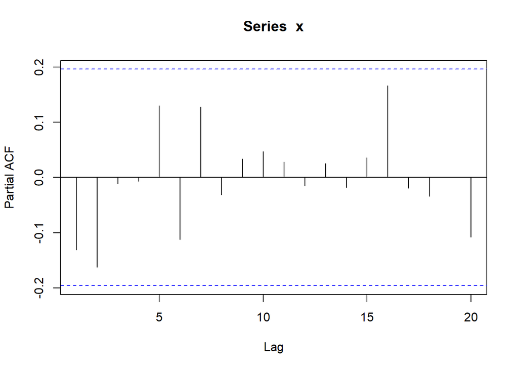

```r
x <- rnorm(100)
pacf(x)    # moznost 1
```

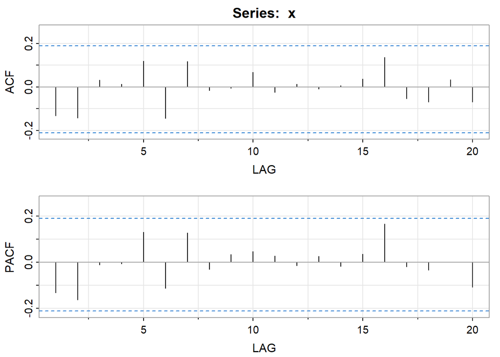

```
##       [,1]  [,2]  [,3]  [,4] [,5]  [,6] [,7]  [,8]  [,9] [,10] [,11] [,12]
## ACF  -0.13 -0.14  0.03  0.01 0.12 -0.14 0.12 -0.02 -0.01  0.07 -0.02  0.01
## PACF -0.13 -0.16 -0.01 -0.01 0.13 -0.11 0.13 -0.03  0.03  0.05  0.03 -0.01
##      [,13] [,14] [,15] [,16] [,17] [,18] [,19] [,20]
## ACF  -0.01  0.01  0.04  0.14 -0.05 -0.07  0.03 -0.07
## PACF  0.03 -0.02  0.04  0.17 -0.02 -0.03  0.00 -0.11
```

```r
acf2(x)    # moznost 2
```

## 3.4 ACF, PACF: Kontrolná otázka

ACF aj PACF sa v R-ku počítajú numericky. Ktoré z nasledujúcich postupností sa po určitom počte členov vynulujú (a teda tie malé čísla sú v skutočnosti nuly) a ktoré majú hodnoty, ktoré konvergujú k nule, ale neexistuje index, od ktorého by boli nulové?

**Príklad 1**

```r
ARMAacf(ar=c(0.05,-0.2), lag.max=10)
```

```
##             0             1             2             3             4
##  1.0000000000  0.0416666667 -0.1979166667 -0.0182291667  0.0386718750
##             5             6             7             8             9
##  0.0055794271 -0.0074554036 -0.0014886556  0.0014166479  0.0003685635
##            10
## -0.0002649014
```

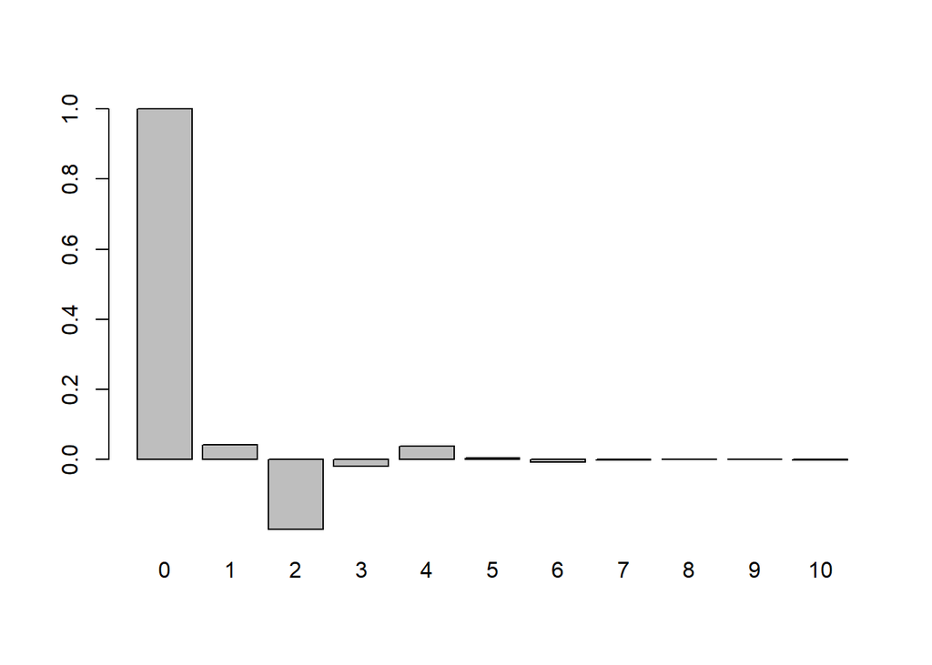

```r
barplot(ARMAacf(ar=c(0.05,-0.2), lag.max=10))
```

**Príklad 2**

```r
ARMAacf(ar=c(0.3,0.05), lag.max=10, pacf=TRUE)
```

```
##  [1]  3.157895e-01  5.000000e-02 -3.863413e-18  3.927096e-19 -4.622862e-19
##  [6] -1.450362e-19 -4.829267e-20  6.640242e-20  5.131096e-20 -2.263719e-20
```

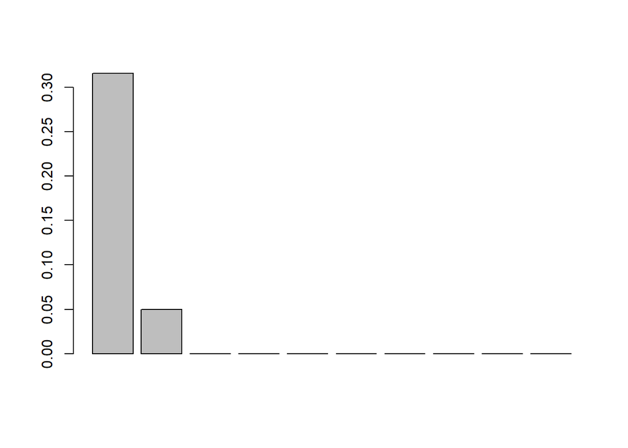

```r
barplot(ARMAacf(ar=c(0.3,0.05), lag.max=10,pacf=TRUE))
```

# 4 Jednotkový koreň

Cieľom tejto časti bude zisťovanie rádu diferencovania časového radu.

Na predošlých cvičeniach sme ukázali, že časový rad môže obsahovať deterministický trend (napríklad lineárny v podobe $\mu t$), ktorý spôsobuje nestacionaritu. Vo väčšine prípadov pozorovaný trend vieme aproximovať polýnomom v premennej $t$ rádu $p$. Následne pri ARMA modelovaní pracujeme s $p$-tými diferenciami časového radu.

Časový rad však môže vykazovať aj iný typ nestacionarity, spôsobenej takzvaným jednotkovým koreňom. Procesy s jednotkovým koreňom nazývame integrované procesy a označujeme ich ako $I(d)$, kde $d$ predstavuje počet diferenciácií potrebných na dosiahnutie stacionarity. To znamená, že pomocou $d$-tych diferencií vieme dostať stacionárny a invertovateľný proces z pôvodného procesu. Vo všeobecnosti, hovoríme, že $y_t$ je $I(d)$, ak ho vieme zapísať ako
$$(1−L)^dy_t=\delta+x_t,$$

pričom $x_t$ je stacionárny a invertovateľný ARMA(p,q) proces.

Na odhalenie prítomnosti jednotkového koreňa v časovom rade budeme používať štatistické testy z balíka `urca` (Unit Root and Cointegration Tests for Time Series Data).

Konkrétne funckiu `ur.df` (ur = unit root, df = Dickey-Fuller):

```r
ur.df(y = časový rad,
      type = jedno z c(
        "trend"  (konštanta aj lineárny trend),
        "drift" (konštanta bez lineárneho trendu) ,
        "none"  (nič)),
      lags = maximálny počet lagov, ktorý uvažujeme,
      selectlags = kritérium, podľa ktorého sa vyberá počet lagov - jedno z c("Fixed", "AIC", "BIC"))
```

## 4.1 Modelový príklad z minimálnej kostry na skúške

Budeme pracovať s dátami o nezamestnanosti, ktoré sú dostupné v balíku `astsa`:

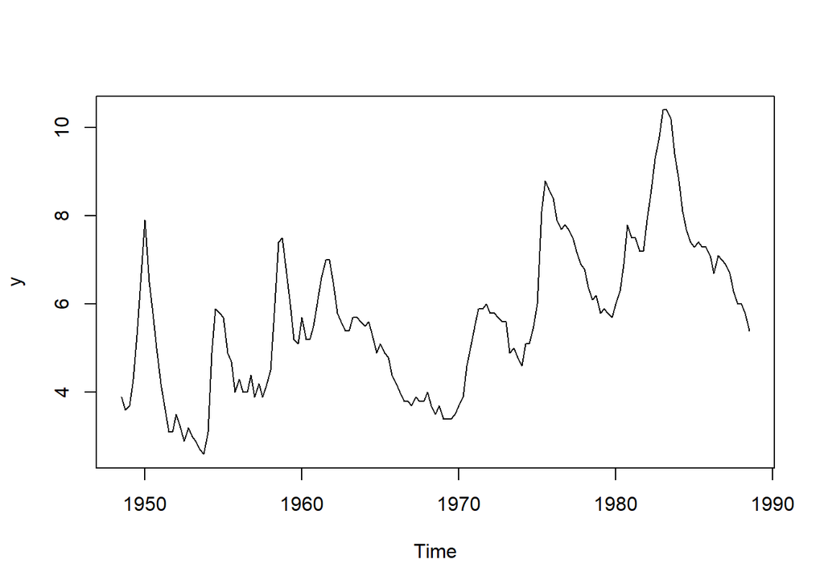

```r
y <- econ5[,"unemp"]
plot(y)
```

Cieľom je nájsť vhodný ARIMA modelu pre uvedené dáta. (Na skúške bývajú dáta podobné týmto, ktoré sú vždy vybrané tak, aby sa pre ne dal nájsť nesezónny ARIMA(p,d,q) model, pričom p ani q nie sú väčšie ako 5).

Zadanie úlohy bude v nasledovnom tvare:

- Vysvetlite, koľkokrát ste dáta diferencovali a prečo. Teda pre každý časový rad (pôvodné dáta, prípadné prvé diferencie, druhé diferencie atď.) napíšte, či ste ich diferencovali a prečo. Skončíme teda tým, že určitý časový rad už diferencovať netreba.
- Súčasťou predchádzajúceho bodu bolo testovanie jednotkového koreňa. V poslednom kroku (po prípadnom predchádzajúcom diferencovaní) nastala situácia, že v dátach nebol ani trend, ani jednotkový koreň, a preto ich nebolo potrebné diferencovať. Podrobne vysvetlite, čo sa tam dialo:
1. Napíšte, s akými parametrami ADF testu ste ich tieto dáta testovali a aká regresia sa odhadla.
2. Aká hypotéza o koeficientoch tejto regresie sa testuje?
3. Odvoďte, že táto hypotéza predstavuje hypotézu o jedotkovom koreni daného časového radu.
4. Kedy túto hypotézu zamietame (ako vyzerá kritérium založené na testovacej štatistike a kritickej hodnote)?
5. Čo vyšlo v našom prípade (zamietame alebo nie) a čo to znamená pre diferencovanie nášho časového radu (diferencujeme alebo nie)?
- Nájdite vhodný ARIMA model pre dáta y. Požiadavky sú: stacionarita, invertovateľnosť a p-hodnoty Ljung-Boxovho testu nad 5 percent. Odpoveď napíšte zapísaním parametrov funkcie `sarima`, ktorou model odhadnete.

**Vzorové riešenie**:

```r
summary(ur.df(y, lags = 5, selectlags = "BIC", type = "drift"))
```

```
##
## ###############################################
## # Augmented Dickey-Fuller Test Unit Root Test #
## ###############################################
##
## Test regression drift
##
##
## Call:
## lm(formula = z.diff ~ z.lag.1 + 1 + z.diff.lag)
##
## Residuals:
##      Min       1Q   Median       3Q      Max
## -1.82251 -0.22532 -0.02061  0.24447  1.89015
##
## Coefficients:
##             Estimate Std. Error t value Pr(>|t|)
## (Intercept)  0.34661    0.12149   2.853  0.00493 **
## z.lag.1     -0.06217    0.02033  -3.059  0.00263 **
## z.diff.lag   0.47257    0.06930   6.819 2.03e-10 ***
## ---
## Signif. codes:  0 '***' 0.001 '**' 0.01 '*' 0.05 '.' 0.1 ' ' 1
##
## Residual standard error: 0.4275 on 152 degrees of freedom
## Multiple R-squared:  0.2507, Adjusted R-squared:  0.2408
## F-statistic: 25.42 on 2 and 152 DF,  p-value: 2.987e-10
##
##
## Value of test-statistic is: -3.0585 4.7181
##
## Critical values for test statistics:
##       1pct  5pct 10pct
## tau2 -3.46 -2.88 -2.57
## phi1  6.52  4.63  3.81
```

Regresia, ktorá sa v teste odhadla je:
$$\Delta z_t = \alpha + c_1 z_{t-1} + c_2 \Delta z_{t-1} +
\epsilon_t$$

2. Testuje sa nasledovná hypotéza o koeficientoch tejto regresie:

$$H_0: c_1=0 \qquad \text{vs.} \qquad
H_1: c_1<0$$

3. Odvodenie, že táto hypotéza predstavuje hypotézu o jedotkovom koreni daného časového radu:

$$\begin{align} \Delta z_t &=\alpha +
c_1 z_{t-1} + c_2 \Delta z_{t-1} + \epsilon_t, \\
(z_t - z_{t-1}) &=\alpha + c_1 z_{t-1} + c_2 (z_{t-1} - z_{t-2}) +
\epsilon_t, \\
z_t &=\alpha + (1+c_1+c_2) z_{t-1} + (-c_2) z_{t-2} + \epsilon_t,
\\
[1 - (1+c_1+c_2)L + c_2 L^2] z_t &= \alpha + \epsilon_t. \end{align}$$

Ak by polynóm $1 - (1+c_1+c_2)L + c_2 L^2$ mal jednotkový koreň, platilo by
$$\begin{align} 1 - (1+c_1+c_2) + c_2 &= 0, \\
- (1+c_1+c_2) + c_2 &= -1, \\
c_1 &= 0. \end{align}$$

Teda vidíme, že hypotéza o testovaní koeficientu $c_1$ z regresie, je totožná s hypotézou o testovaní jednotkového koreňa.

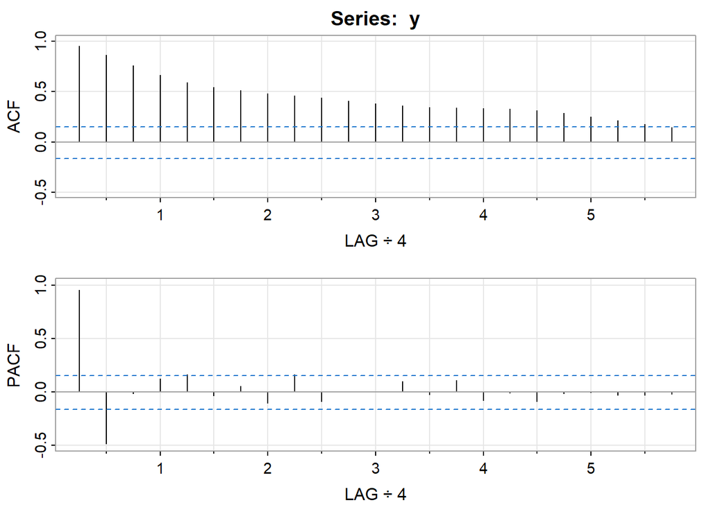

```
##      [,1]  [,2]  [,3] [,4] [,5]  [,6] [,7]  [,8] [,9] [,10] [,11] [,12] [,13]
## ACF  0.95  0.86  0.76 0.66 0.59  0.54 0.51  0.48 0.46  0.44  0.41  0.38  0.36
## PACF 0.95 -0.48 -0.01 0.12 0.16 -0.03 0.05 -0.10 0.16 -0.09  0.01  0.01  0.10
##      [,14] [,15] [,16] [,17] [,18] [,19] [,20] [,21] [,22] [,23]
## ACF   0.34  0.34  0.33  0.33  0.31  0.29  0.25  0.21  0.18  0.14
## PACF -0.03  0.11 -0.08 -0.01 -0.09 -0.01  0.00 -0.03 -0.03 -0.02
```

Vyzerá to tak, že vhodný model pre naše dáta by mohol byť AR(2). Dôvod je ten, že PACF(k), pre k > 2 je takmer nulová, zatiaľ čo ACF je nenulová a postupne klesá.

```
## <><><><><><><><><><><><><><>
##
## Coefficients:
##       Estimate     SE t.value p.value
## ar1     1.4389 0.0674 21.3471       0
## ar2    -0.5064 0.0677 -7.4840       0
## xmean   5.6034 0.4816 11.6340       0
##
## sigma^2 estimated as 0.1829345 on 158 degrees of freedom
##
## AIC = 1.207742  AICc = 1.208692  BIC = 1.284299
##
```

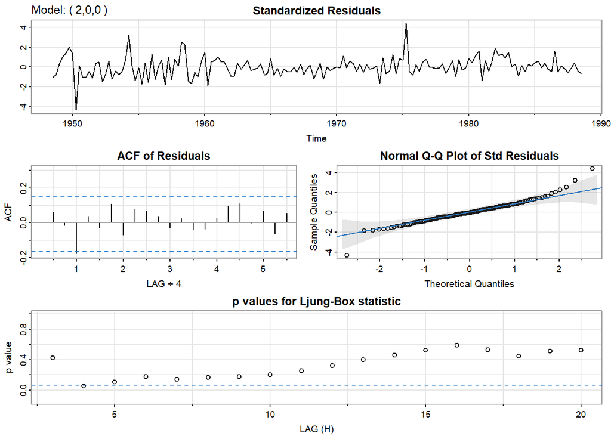

```r
model.y <- sarima(y,2,0,0)
```

Pre `lag=4` z grafu nie je jasné, či je p-hodnota väčšia ako 5% alebo nie. Overme si to priamo výpočtom

```r
Box.test(...)$p.value
```

```
## [1] 0.05157508
```

Dostávame, že uvedená p-hodnota Ljung-Boxovho je väčšia ako 5%. Z grafu vidíme, že všetky ostatné p-hodnoty sú tiež väčšie ako 5%. Invertovateľnosť overovať netreba, keďže nemáme MA členy. Overíme ešte stacionaritu. Použitím regulárnym výrazov vieme k odhadnutým AR koeficientom pristupovať nasledovne:

```r
koef <- model.y$fit$coef
koef_ar <- koef[grep("^ar",names(koef))]
```

Absolútne hodnoty koreňom polynómu potom sú

```r
abs(polyroot(c(1,-koef_ar)))
```

```
## [1] 1.211715 1.629720
```

Oba korene ležia mimo jednotkového kruhu, preto proces `sarima(y,2,0,0)` je stacionárny.

# 5 Blízke koreňe AR a MA časti

Vygenerujeme dáta z ARMA(2,1) procesu:

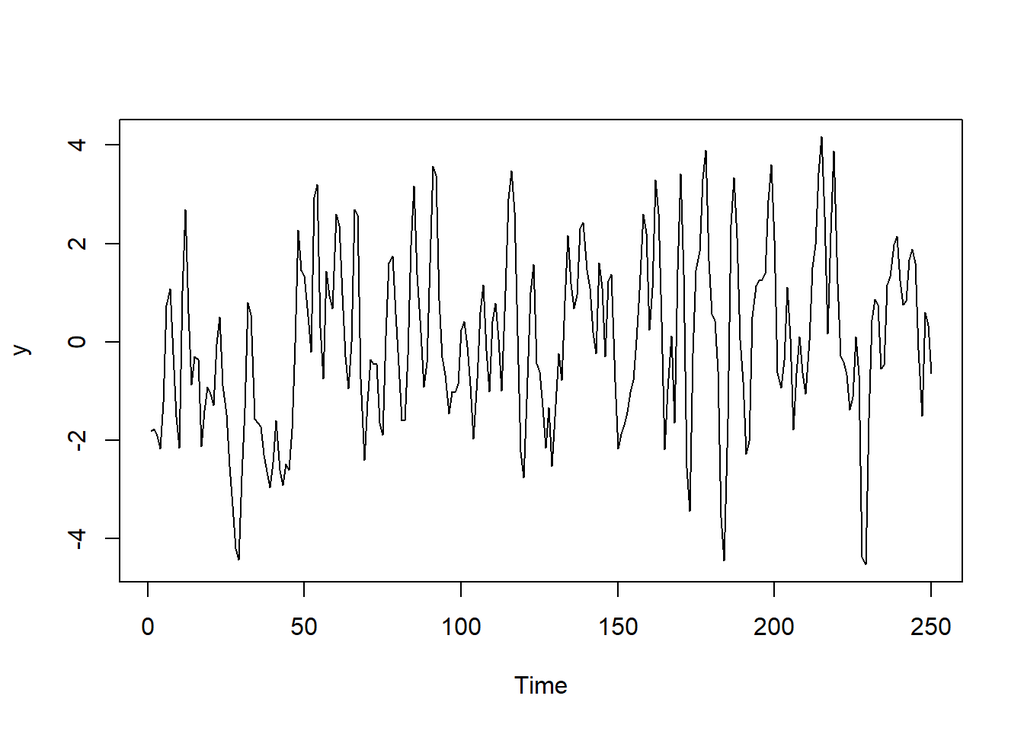

```r
set.seed(1234)
y <- arima.sim(model=list(ar=c(0.4,-0.1), ma=c(0.8)), n=250)
plot(y)
```

Odhadneme ARMA(3,2) model:

```r
model32 <- sarima(y,3,0,2, details = FALSE)
```

```
## <><><><><><><><><><><><><><>
##
## Coefficients:
##       Estimate     SE t.value p.value
## ar1     1.2508 0.4442  2.8161  0.0053
## ar2    -0.5125 0.2458 -2.0851  0.0381
## ar3     0.1126 0.0821  1.3714  0.1715
## ma1     0.0941 0.4424  0.2126  0.8318
## ma2    -0.6013 0.3753 -1.6020  0.1105
## xmean   0.0233 0.2077  0.1122  0.9107
##
## sigma^2 estimated as 0.9982311 on 244 degrees of freedom
##
## AIC = 2.901126  AICc = 2.902509  BIC = 2.999727
##
```

Graficky znázornite korene polynómov pre AR a pre MA časť procesu (ako body v komplexnej rovine, na x-ovej osi bude reálna časť čísla, na y-ovej imaginárna), pričom vhodným spôsobom odlíšte, ktorý koreň zodpovedá ktorému polynómu. Na grafe by ste mali vidieť, že jeden z koreňov AR časti je veľmi blízko jednému z koreňov MA časti.

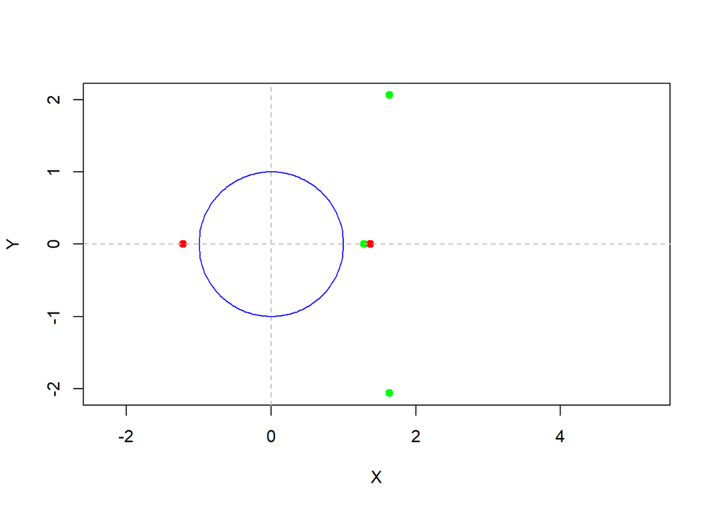

Čomu tento výsledok nasvedčuje? Ako by malo ďalej pokračovať modelovanie týchto dát?

# 6 AR(1) proces pozorovaný s chybou

Vygenerjeme AR(1) proces $y$:

```r
set.seed(12345)
y <- arima.sim(n=200, list(ar = c(0.9)), sd=0.1)
```

Pozorovať ho ale budeme s chybou `eps`, vidíme teda proces $x$:

```r
eps <- rnorm(200)/15
x <- y+eps
```

Zobrazte vygenerované procesy $y$ (pôvodný - čiernou) a $x$ (pozorovaný - modrou).

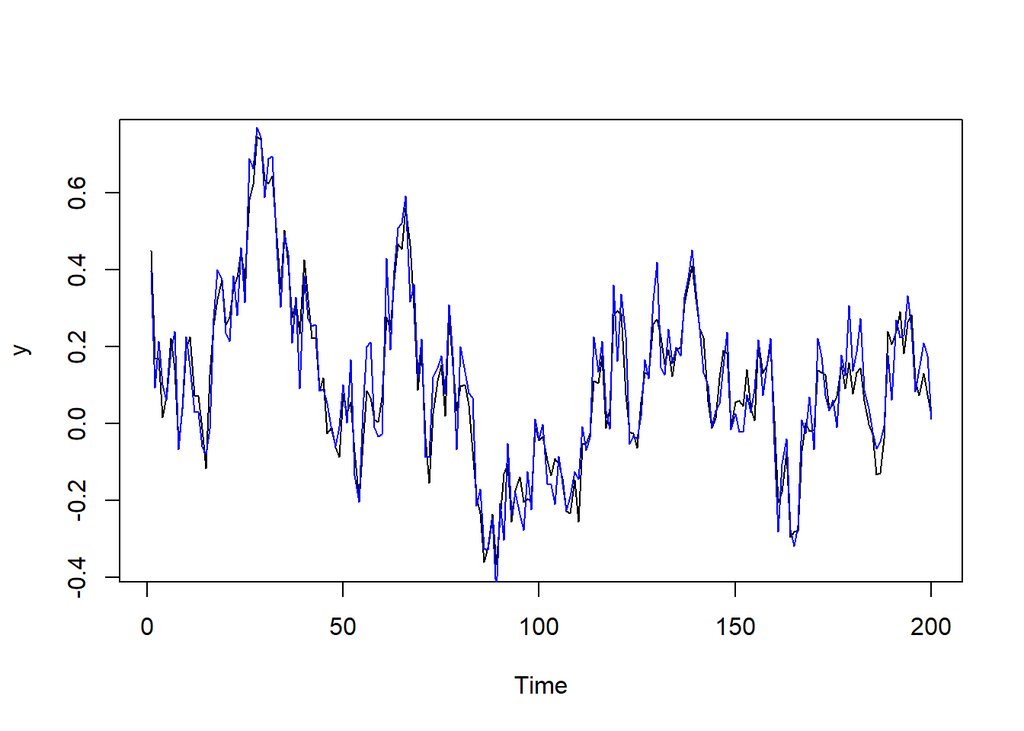

Ukážte, že:

- AR(1) je dobrý model pre dáta $y$ - to je prirodzené, tak sme ich generovali
- Ale AR(1) nie je dobrý model pre dáta $x$ (chyba pri pozorovaní procesu, aj keď nie je veľká, teda spôsobuje problém)
- ARMA(1,1) je dobrý model pre dáta $x$.

Poslednú vlastnosť dokážte aj analyticky (nielen pre vygenerované dáta) - teda ak $y$ je AR(1) a $x=y+\epsilon$, kde $\epsilon$ je proces definovaný tak, ako v simuláciách hore, tak $x$ sa dá zapísať ako ARMA(1,1) proces.

# 7 Dáta na samostatnú prácu

Zadanie a otázky sú vždy rovnaké ako v modelovom príklade.

## 7.1 Dáta *BJsales* z knižnice `datasets`

Popis dát z helpu: The sales time series BJsales and leading indicator BJsales.lead each contain 150 observations.

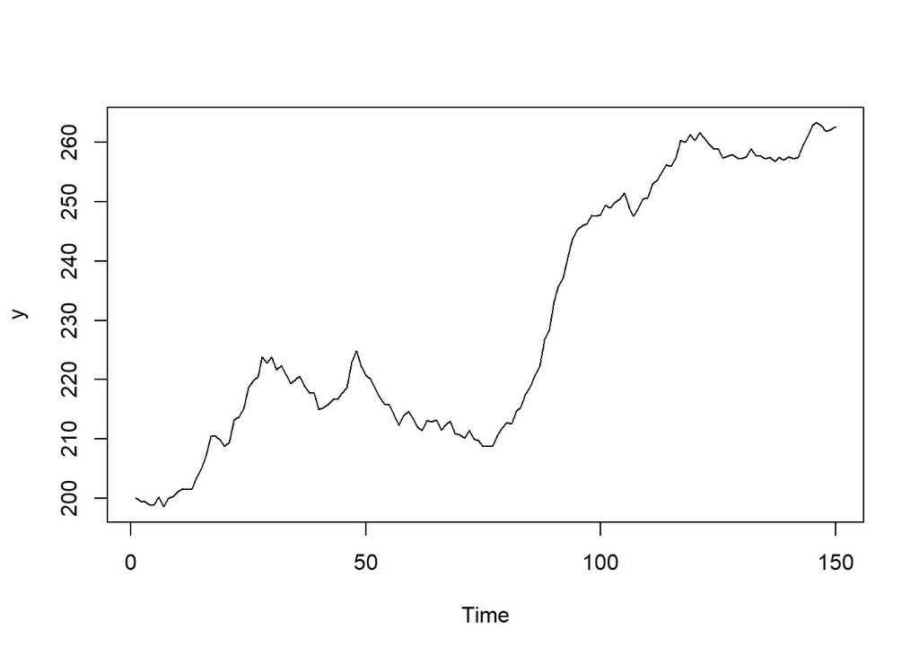

```r
y <- BJsales
plot(y)
```

## 7.2 Dáta *WWWusage* z knižnice `datasets`

Popis dát z helpu: A time series of the numbers of users connected to the Internet through a server every minute.

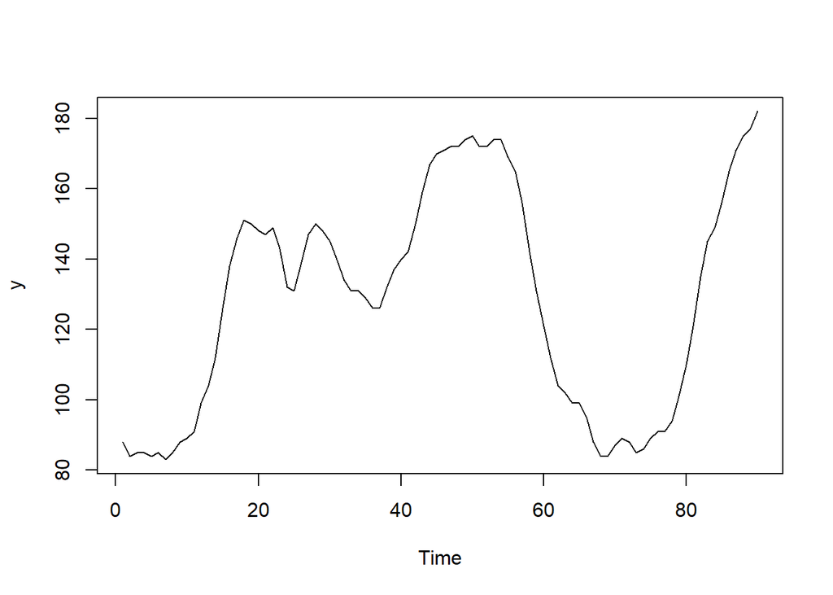

```r
y <- window(WWWusage, start=1, end=90)
plot(y)
```

## 7.3 Dáta *faithful* z knižnice `datasets`

Popis dát z helpu: Waiting time between eruptions and the duration of the eruption for the Old Faithful geyser in Yellowstone National Park, Wyoming, USA.

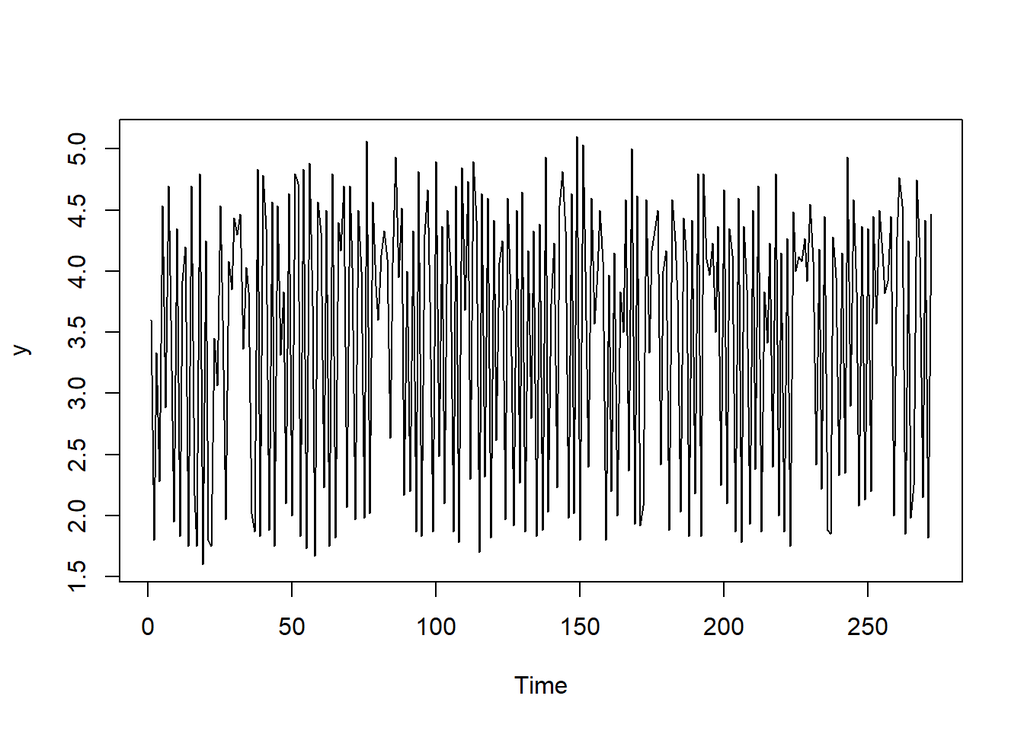

```r
y <- ts(faithful[, 1])
plot(y)
```

## 7.4 Dáta *blood* z knižnice `astsa`

Popis dát z helpu: Multiple time series of measurements made for 91 days on the three variables, log(white blood count) [WBC], log(platelet) [PLT] and hematocrit [HCT]. Missing data code is NA.

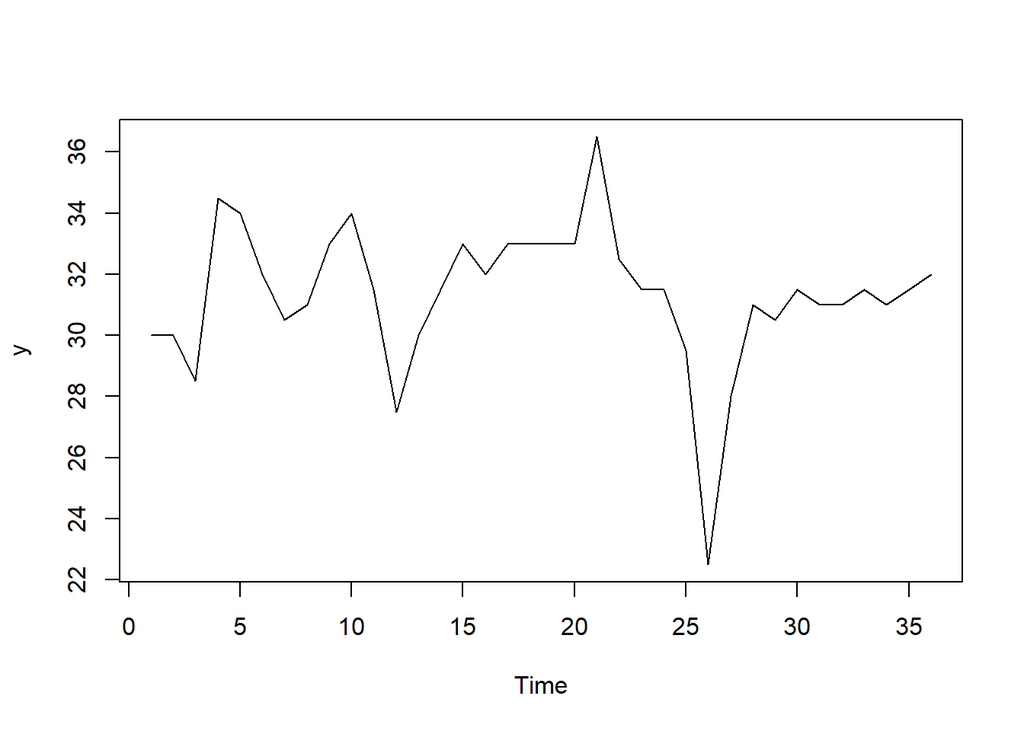

```r
y <- ts(blood[1:36, 3])
plot(y)
```

## 7.5 Dáta *gnp* z knižnice `astsa`

Popis dát z helpu: Seasonally adjusted quarterly U.S. GNP from 1947(1) to 2002(3).

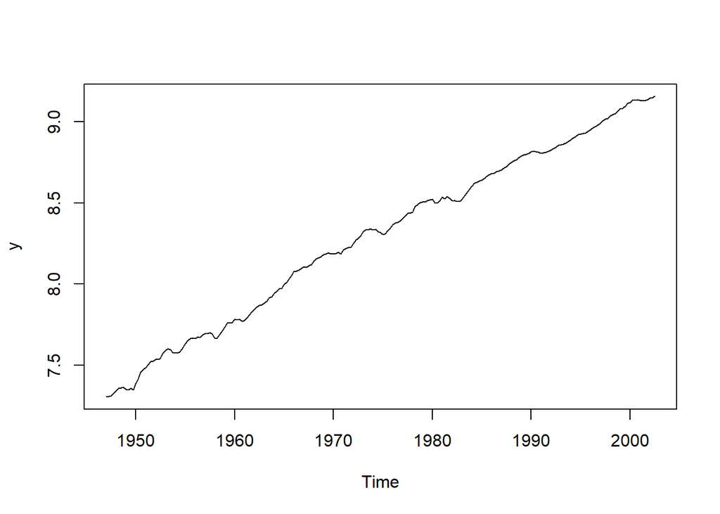

```r
y <- log(gnp)
plot(y)
```